# Modelos de predicción económica a partir de redes sociales.

### Francisco Alonso Fernández. Afi Escuela de Finanzas: Máster en Data Science & Big Data

## Introducción

Con la entrada de siglo comenzó también la llegada paulatina de las redes sociales, que vino de la mano con el acceso masivo y gratuito a Internet. Desde ese momento, empieza a generarse una cantidad ingente de datos: todos estamos conectados permanentemente, ya sea mandado un whatsapp, publicando nuestra última foto en Facebook o leyendo el último trending topic en Twitter. Con ello, cada persona deja tras de sí un rastro que conocemos como huella digital.

[figure not shown]

Entre todos los datos que contiene esta huella digital sobre una persona se encuentran, entre otros; lugares de residencia, estudios, puestos de trabajo, intereses (incluso tendencias políticas y religiosas), aficiones, infracciones, sanciones administrativas… lo que, sin duda, aporta una información muy preciada a la hora de elaborar. Claros ejemplos son las herramientas de marketing que proporcionan las propias redes sociales, como por ejemplo Facebook, que permite a los anunciantes la compra de espacios publicitarios totalmente dirigidos gracias a una segmentación tremendamente detallada.

Una de las áreas más tradicionalistas que podrá aprovechar esta explosión digital es la de Recursos Humanos. Muy poco se ha innovado en este sector desde, probablemente, la incorporación de tests psicológicos, pruebas de aptitud, etc, en los procesos de selección. Pero todo esto ocurrió antes incluso de la llegada del siglo XXI. Con la transformación digital, lo único que se ha realizado es una digitalización de los procesos de RRHH pero la explotación del dato es algo que está comenzando a aparecer y en lo que se empieza a tomar conciencia.

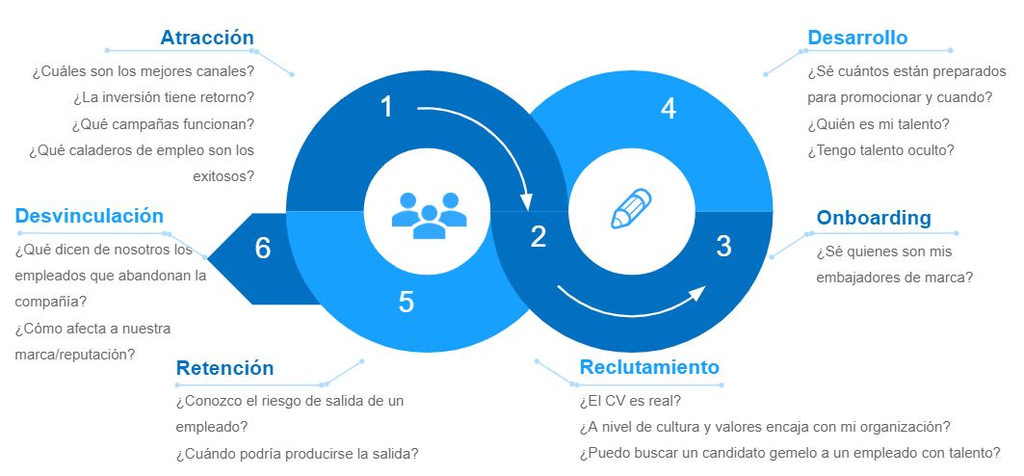

El recurso más extendido que da apoyo a los procesos de selección es el currículum vítae. Pocas empresas incorporan otros tipos de tests, incluso conociendo que la mayor fiabilidad y validez que se obtendría con un test de inteligencia. Estas otras pruebas no se suelen realizar por considerarse intrusivas y por tanto, no estar bien valoradas por los candidatos. Sin embargo, con la huella digital se abre un mundo de información que puede ser explotada y utilizada en cualquier proceso de recursos humanos. A partir de los datos del currículum, como el nombre, el teléfono o el email, pueden localizarse las redes sociales a las que está suscrito un candidato y por tanto, se puede acceder a su información.

En cualquier caso, la descarga de la información de RRSS y su posterior tratamiento, no pueden realizarse sin el consentimiento del candidato para cumplir con el Reglamento General de Protección de Datos (RGDP). Esto es algo que a día de hoy se está haciendo, por lo que podremos consultar la huella digital de una persona y, en particular, sus redes sociales, donde encontraremos información no estructurada que tendrá que ser analizada. El análisis realizado por una persona, está sujeto a una serie de sesgos cognitivos, por lo que surge la necesidad de incorporar procesos automáticos que ayuden en la toma de decisión, es decir, en la valoración de un candidato. Es así como surgen los siguientes retos:

- Predicción sobre la personalidad. Si se trata de una candidatura para un puesto de trabajo, el equipo de Recursos Humanos podría estar interesado en tener una información acerca de los rasgos de personalidad del candidato, que apoye a determinar el grado de ajuste a una determinada vacante. Cada puesto de trabajo requerirá una personalidad diferente, alguien que trabaje en un Centro de Procesamiento de Datos (CPD), sin contacto humano, será muy diferente de alguien que trabaje como comercial, por ejemplo.
- Predicción salarial o del nivel económico. Si la candidatura es para optar a una beca de estudios, optar a una plaza de máster… Podría ser interesante tener una primera aproximación del nivel económico del candidato para ver si podría hacer frente o no a los costos asociados.

En este trabajo nos enfocaremos en el segundo punto. Se pretende hacer uso de técnicas de Machine Learning y Text Mining con información proveniente de redes sociales (Twitter, LinkedIn y Facebook), para tratar de hacer una estimación económica del candidato.

El nivel económico se trata de una información sensible pero a la vez tremendamente útil sobre las personas. De acuerdo a un artículo publicado por la revista Forbes, menos del 10% de las personas proporciona abiertamente información sobre sus ingresos. De igual manera, es un tema del que la gente suele ser reticente a comentar con compañeros de trabajo o amigos. Aunque, parece que últimamente se ha puesto de moda preguntar, a los invitados de cierto programa de televisión, por los ingresos, no es la tónica normal.

Me gustaría cerrar esta introducción con una pequeña reflexión respecto a las aplicaciones que pueden tener este tipo de campañas de marketing realizadas a partir de modelos de predicción cómo el de este trabajo. Y es que, mal usados, este tipo de resultados pueden perpetuar las desigualdades existentes entre los candidatos, llegando incluso a generar un circulo vicioso que no haga más que, por ejemplo, continuar con la discriminación de grupos minoritarios. Es por ello, que su uso debe ser parte de un proceso más amplio en el que se tengan en cuenta entrevistas personales, pruebas de validez, historial del cadidato, etc, y nunca tomar decisiones únicamente basadas en las predicciones.

### Investigación previa

El proyecto se inicia con una investigación que tiene por objetivo encontrar posibles soluciones técnicas, pistas sobre las variables relevantes o, incluso, juegos de datos que podamos usar para el proceso de construcción del modelo. En ella se han buscado proyectos que hayan abordado una problemática similar, como, por ejemplo, aquellos en los que se busca la predicción del poder adquisitivo, del nivel económico o del riesgo de impago de una persona. Además, se ha dado gran relevancia a intentar localizar aquellos casos basados en la predicción a partir de datos de perfiles digitales.

No resulta difícil encontrar artículos que plantean la posibilidad de realizar este tipo de proyectos, basta con hacer una búsqueda del tipo ‘predict salary digital footprint’ para encontrar una buena cantidad de ellos. Sin embargo, la proporción de artículos significativos es relativamente baja. Si nos centramos en casos de literatura académica o en artículos en los que se escriba sobre un proyecto real, podemos destacar, dentro de la pequeña investigación realizada, las siguientes referencias:

- [Predicting individual-level income from Facebook profiles](https://www.ncbi.nlm.nih.gov/pmc/articles/PMC6438464/)
- [On the Rise of FinTechs - Credit Scoring using Digital Footprints](https://editorialexpress.com/cgi-bin/conference/download.cgi?db_name=AFA2019&paper_id=119)
- [What Your Email Address Says About Your Credit Worthiness](https://www.fuqua.duke.edu/duke-fuqua-insights/puri-credit-worthiness)

Volver arriba

## Correo electrónico

Puede darse el caso de que un candidato no tenga redes sociales, o incluso que las tenga pero no estén asociadas a su nombre ni a su email, o que en definitiva no encontremos rastro de su huella digital.

En estos casos, sabemos que como poco tendremos el email y el nombre. Antes que no dar ninguna información, lo que se ha decidido hacer es mirar la extensión del email, ya que esta suele ir asociada al dominio de un país (por ejemplo: .es de España o .ie de Irlanda), y asociar al usuario el salario medio del país correspondiente. De esta manera tenemos un pequeño dato más con el que constrastar y que nos puede permitir encontrar incongruencias con otras fuentes, por ejemplo el currículum.

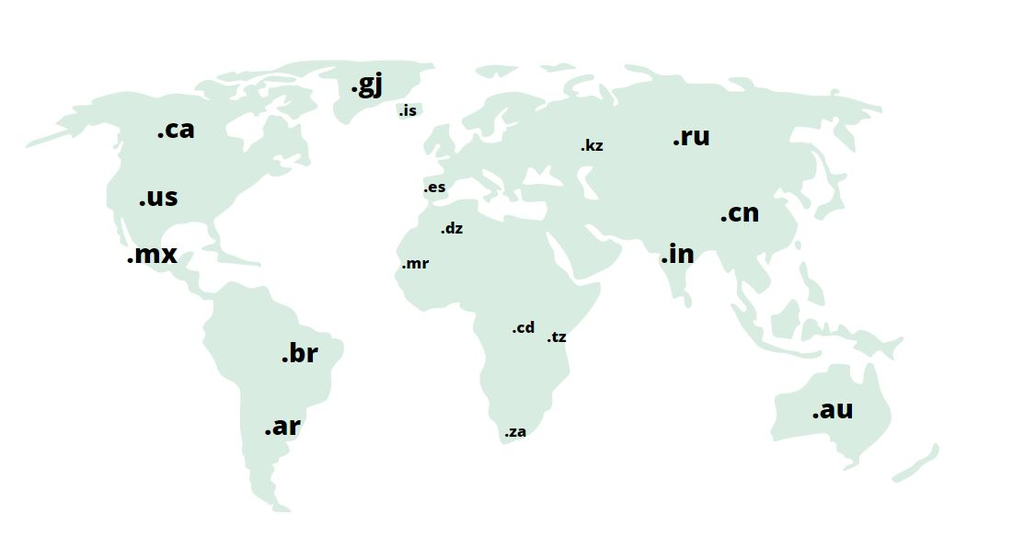

Dominios nacionales

##### Fuentes y datos

La siguiente tabla indica los dominios de nivel superior geográfico para la gran mayoría de países. Han sido extraídos de la base de datos para dominios de internet: [Internet Assigned Numbers Authority](https://www.iana.org/domains/root/db). Además, la tabla contiene una columna de observaciones que puede contener aclaraciones para determinados países que pueden dar lugar a dudas.

|  | Dominio | País o región | Observaciones |
| --- | --- | --- | --- |
| 1 | .ac | Isla Ascensión | Parte del Territorio británico de ultramar de Santa Elena, Ascensión y Tristán de Acuña |
| 2 | .ad | Andorra |  |
| 3 | .ae | Emiratos Árabes Unidos |  |
| 4 | .af | Afganistán |  |
| 5 | .ag | Antigua y Barbuda |  |
| 6 | .ai | Anguila | Territorio británico de ultramar |
| 7 | .al | Albania |  |
| 8 | .am | Armenia |  |
| 9 | .ao | Angola |  |
| 10 | .aq | Antártida | Definidas por el Tratado Antártico como todo lo que quede al sur del paralelo 60°S |

[output cut: 234 more lines]

## Facebook

En esta red social disponemos de una enorme cantidad de información sobre un usuario, ya que, además de compartir fotos y escribir comentarios, tiene una inmensa lista de funcionalidades entre las que encontramos, por ejemplo: marcar nuestros intereses, hacer reviews de lugares visitados, unirse a grupos, crear eventos… En definitiva es una red social que tiene influencia directamente en la política, en la cultura y en la opinión pública de los usuarios, por lo que, a priori, es la más interesante y la que más información nos va a proporcionar a la hora de hacer una predicción económica de los usuarios.

En adición a ello, y como hemos mencionado en capítulos anteriores, la comunidad latinoamericana lo tiene claro en lo que a redes sociales se refiere: Facebook es su favorita. De hecho, se estima que Facebook cuenta con una penetración en la región de en torno al 40%, lo que supone alrededor del 70% de los usuarios latinoamericanos de Internet, y un 93% de los que usan redes sociales. Nótese que este último dato es de especial interés para nuestro objetivo, ya que significa que en la inmensa mayoría de los usuarios para los que encontremos huella digital, Facebook formará parte de dicha huella.

### Enriquecimiento

Con el objetivo de sacar provecho de las localizaciones encontradas en Facebook, trataremos de pasar esa información categórica a un valor numérico como es el PIB. De esta manera conseguimos un predictor bastante valioso para nuestro modelo.

#### Países

##### Fuentes y datos

Los datos a nivel de países han sido extraídos del Banco Mundial, en particular de sus [estudios sobre el PIB per cápita](https://datos.bancomundial.org/indicador/NY.GDP.PCAP.CD).

Dicho estudio, aporta el histórico de datos hasta el añp 2018 inclusive. Por tanto los datos que utilizaremos y que se muestran a continuación son para este último año. En cualquier caso, disponer del histórico puede ser útil por si más adelante quisiéramos hacer una estimación por regresión para valores futuros del PIB.

Cabe destacar que las cifras serán aportadas siempre en dólares estadounidenses.

Por último, mencionar que de los 265 países registrados actualmente, se dispone de información actualizada para 240, entre ellos todos los países de Latinoamérica.

|  | País | Código de país | PIB per cápita ($) | PIB per cápita mensual ($) |
| --- | --- | --- | --- | --- |
| 1 | Aruba | ABW |  |  |
| 2 | Afganistán | AFG | 520,8966027 | 43,40805023 |
| 3 | Angola | AGO | 3432,385736 | 286,0321447 |
| 4 | Albania | ALB | 5268,848504 | 439,0707086 |
| 5 | Andorra | AND | 42029,76274 | 3502,480228 |
| 6 | El mundo árabe | ARB | 6608,806978 | 550,7339148 |
| 7 | Emiratos Árabes Unidos | ARE | 43004,95336 | 3583,746113 |
| 8 | Argentina | ARG | 11683,94962 | 973,6624685 |
| 9 | Armenia | ARM | 4212,070943 | 351,0059119 |
| 10 | Samoa Americana | ASM | 11466,69071 | 955,5575588 |

[output cut: 254 more lines]

Volver arriba

#### Regiones

##### Chile

###### División territorial

Chile es un país divido actualmente en 16 regiones:

- Metropolitana de Santiago
- Antofagasta
- Valparaíso
- Biobío
- O’Higgins
- Maule
- Los Lagos
- Coquimbo
- Araucanía
- Tarapacá
- Atacama
- Los Ríos
- Magallanes
- Arica y Parinacota
- Aysén
- Ñuble

Es importante destacar que la región de Ñuble entró en vigor en septiembre de 2018, hasta entonces era considerada parte de la región de Biobío. Por ello, como nuestros datos son de 2018, aun consideramos Ñuble como parte de Biobío.

###### Fuentes

Los datos han sido extraídos del Banco Central de Chile, portal de referencia para los estudios estadísticos en este país. Corresponden a sus estudios sobre el [PIB regional](https://www.bcentral.cl/areas/estadisticas/pib-regional), realizados en 2018 como se mencionó anteriormente.

###### Datos

Como haremos para cada uno de los países objetivo, nos vamos a basar en el PIB para obtener el PIB per cápita y una estimación mensual. Cabe recalcar que para esta primera estimación no estamos teniendo en cuenta la componente estacional a la hora de calcular el PIB per cápita mensual. Además, para Chile los datos venían dados diréctamente en dólares, por lo que no ha sido necesario hacer ningún tipo de cambio.

De Chile disponemos también de otros datos como, para cada región, un país que tenga aproximadamente el mismo PIB, que sirve como indicador de la situación económica. Pero para unificar el formato con el resto de países no se muestran en la siguiente tabla.

Obsérvese también, que en la última fila tenemos los valores agregados para el país.

|  | Región | PIB (M. de $) | Población | PIB per cápita ($) | PIB per cápita mensual ($) |
| --- | --- | --- | --- | --- | --- |
| 1 | Metropolitana de Santiago | 124010 | 7112808 | 17434,74588 | 1452,89549 |
| 2 | Antofagasta | 27738 | 607534 | 45656,70399 | 3804,725332 |
| 3 | Valparaíso | 24307 | 1815902 | 13385,63425 | 1115,469521 |
| 4 | Biobío | 22746 | 1556805 | 14610,69305 | 1217,557755 |
| 5 | O'Higgins | 13323 | 914555 | 14567,7406 | 1213,978383 |
| 6 | Maule | 10217 | 1044950 | 9777,501316 | 814,7917763 |
| 7 | Los Lagos | 10197 | 828708 | 12304,69598 | 1025,391332 |
| 8 | Coquimbo | 8290 | 757586 | 10942,65206 | 911,8876713 |
| 9 | Araucanía | 7783 | 957224 | 8130,803239 | 677,5669366 |
| 10 | Tarapacá | 6708 | 330558 | 20292,95918 | 1691,079932 |

[output cut: 6 more lines]

Volver arriba

##### Colombia

###### División territorial

Colombia es un país divido en 32 departamentos y un distrito capital, Bogotá:

- Vichada
- Vaupés
- Valle del Cauca
- Tolima
- Sucre
- Santander
- San Andrés y Providencia
- Risaralda
- Quindío
- Putumayo
- Norte de Santander
- Nariño
- Meta
- Magdalena
- La Guajira
- Huila
- Guaviare
- Guainía
- Cundinamarca
- Córdoba
- Chocó
- Cesar
- Cauca
- Casanare
- Caquetá
- Caldas
- Boyacá
- Bolívar
- Bogotá
- Atlántico
- Arauca
- Antioquia
- Amazonas

###### Fuentes

EL DANE (Departamento Administrativo Nacional de Estadísticas) se trata de la principal fuente de referencia, ya que se trata del principal instituto estadístico del país. En concreto hemos consultado su apartado de [Cuentas nacionales departamentales](https://www.dane.gov.co/index.php/estadisticas-por-tema/cuentas-nacionales/cuentas-nacionales-departamentales).

Cabe mencionar que el informe más actualizado que se ha encontrado es de 2018. Por ello, el tipo de cambio que se ha usado para pasar los datos de pesos colombianos a dólares ha sido el del 9 de marzo de 2018, que además coincide prácticamente con el valor medio de la divisa en dicho año.

###### Datos

Como haremos para cada uno de los países objetivo, nos vamos a basar en el PIB para obtener el PIB per cápita y una estimación mensual. Cabe recalcar que para esta primera estimación no estamos teniendo en cuenta la componente estacional a la hora de calcular el PIB per cápita mensual.

Además, para Colombia disponemos de datos como la participación de cada departamento a nivel nacional, siendo Bogotá y Antioquia los que más aportan. Pero para unificar el formato con el resto de países no se muestran en la siguiente tabla.

Obsérvese también, que en la última fila tenemos los valores agregados para el país.

|  | Departamento | PIB (M. de $) | Población | PIB per cápita ($) | PIB per cápita mensual ($) |
| --- | --- | --- | --- | --- | --- |
| 1 | Vichada | 215 | 77276 | 2785,082044 | 232,0901703 |
| 2 | Vaupés | 95 | 44928 | 2111,378205 | 175,9481838 |
| 3 | Valle del Cauca | 32311 | 4755760 | 6793,980352 | 566,1650294 |
| 4 | Tolima | 7135 | 1419957 | 5024,490178 | 418,7075149 |
| 5 | Sucre | 2779 | 877024 | 3168,852848 | 264,0710707 |
| 6 | Santander | 21500 | 2090854 | 10282,66919 | 856,8890989 |
| 7 | San Andrés y Providencia | 503 | 78413 | 6417,303253 | 534,7752711 |
| 8 | Risaralda | 5369 | 967780 | 5547,686458 | 462,3072048 |
| 9 | Quindío | 2661 | 574960 | 4627,278419 | 385,6065349 |
| 10 | Putumayo | 1354 | 358896 | 3773,293656 | 314,441138 |

[output cut: 24 more lines]

Volver arriba

##### Ecuador

###### División territorial

Ecuador es un país divido político-administrativamente en 24 provincias:

- Azuay
- Bolívar
- Cañar
- Carchi
- Cotopaxi
- Chimborazo
- El Oro
- Esmeraldas
- Guayas
- Imbabura
- Loja
- Los Ríos
- Manabí
- Morona Santiago
- Napo
- Pastaza
- Pichinga
- Tungurahua
- Zamora Chinchipe
- Galápagos
- Sucumbíos
- Orellana
- Santo Domingo
- Santa Elena

###### Fuentes

Los datos aquí presentes provienen del Banco Centrla de Ecuador en su seccción sobre [Información Económica](https://www.bce.fin.ec/index.php/informacioneconomica).

Además ha sido necesario, para el cálculo del PIB per cápita, contar de datos de población de cada una de las provincias. Éstos han sido obtenidos de Wikipedia y sus artículo de [Provincias de Ecuador](https://es.wikipedia.org/wiki/Provincias_de_Ecuador).

###### Datos

Como hasta ahora, nos vamos a basar en el PIB para obtener el PIB per cápita y una estimación mensual. Cabe recalcar que para esta primera estimación no estamos teniendo en cuenta la componente estacional a la hora de calcular el PIB per cápita mensual. Además, para Ecuador los datos venían dados diréctamente en dólares, por lo que no ha sido necesario hacer ningún tipo de cambio.

Obsérvese también, que en la última fila tenemos los valores agregados para el país.

|  | Provincia | PIB (M. de $) | Población | PIB per cápita ($) | PIB per cápita mensual ($) |
| --- | --- | --- | --- | --- | --- |
| 1 | Azuay | 5343 | 881394 | 6062,407846 | 505,2006539 |
| 2 | Bolívar | 639 | 209933 | 3043,690657 | 253,6408881 |
| 3 | Cañar | 1065 | 281396 | 3785,386046 | 315,4488372 |
| 4 | Carchi | 664 | 186869 | 3553,157051 | 296,0964209 |
| 5 | Cotopaxi | 1953 | 488716 | 3995,900893 | 332,9917411 |
| 6 | Chimborazo | 1854 | 524004 | 3539,009799 | 294,9174833 |
| 7 | El Oro | 3571 | 715751 | 4988,958791 | 415,7465659 |
| 8 | Esmeraldas | 3087 | 643654 | 4795,794287 | 399,6495239 |
| 9 | Guayas | 26637 | 4387434 | 6071,232319 | 505,9360266 |
| 10 | Imbabura | 1930 | 476257 | 4053,266555 | 337,7722129 |

[output cut: 15 more lines]

Volver arriba

##### México

###### División territorial

México es un país divido en 32 entidades federativas (31 estados y un distrito federal correspondiente con la cápital):

- Aguascalientes
- Baja California
- Baja California Sur
- Campeche
- Chiapas
- Chihuahua
- Coahuila de Zaragoza (también Coahuila)
- Colima
- Ciudad de México (también Distrito Federal, México DF o DF)
- Durango
- Estado de México (también México)
- Guanajuato
- Guerrero
- Hidalgo
- Jalisco
- Michoacán de Ocampo (también Michoacán)
- Morelos
- Nayarit
- Nuevo León
- Oaxaca
- Puebla
- Querétaro
- Quintana Roo
- San Luis Potosí
- Sinaloa
- Sonora
- Tabasco
- Tamaulipas
- Tlaxcala
- Veracruz de Ignacio de la Llave (también Veracruz)
- Yucatán
- Zacatecas

###### Fuentes

El INEGI (Instituto Nacional de Estadística y Geografía de Mexico) es considerado en este estudio como la principal fuente de referencia, ya que es una fuente fiable propiamente mexicana. De entre todos los datos que pueblica, hemos rescatado el [COMUNICADO DE PRENSA NÚM. 644/18](https://www.inegi.org.mx/contenidos/saladeprensa/boletines/2018/OtrTemEcon/PIBEntFed2017.pdf), ya que es el informe más recietne que hemos podido localizar sobre el producto interior bruto de las entidades federattivas de México.  
Así mismo se han consultado dos artículos de la wikipedia, cuyos datos proceden principalmente del INEGI: [Anexo:Estados de México por PIB](https://es.wikipedia.org/wiki/Anexo:Entidades_federativas_de_M%C3%A9xico_por_PIB).

Para el cálculo per cápita han sido necesarios datos de la población de cada estado, obtenidos de nuevo en Wikipedia. En concreto en su [Anexo: Entidades federativas de México por superficie, población y densidad](https://es.wikipedia.org/wiki/Anexo:Entidades_federativas_de_M%C3%A9xico_por_superficie,_poblaci%C3%B3n_y_densidad)

###### Datos

Como haremos para cada uno de los países objetivo, nos vamos a basar en el PIB para obtener el PIB per cápita y una estimación mensual. Cabe recalcar que para esta primera estimación no estamos teniendo en cuenta la componente estacional a la hora de calcular el PIB per cápita mensual. Además, para México los datos venían dados en pesos méxicanos, por lo que es importante recalcar que el cambio usado ha sido la media de ese año, 0.052 dólares por peso mexicano. Recalcar que el peso méxicano no para de caer en los últimos tiempos y actualmente en cambio está apróximadamente a 0.041 dólares el peso mexicano.

Se dispone también, para México, de otros datos como, un histórico del PIB departamental en los últimos diez años, que podría ser útil para estimar futuros PIB mediante regresión. Pero para unificar el formato con el resto de países no se muestran en la siguiente tabla.

Obsérvese también, que en la última fila tenemos los valores agregados para el país.

|  | Estado | PIB (M. de $) | Población | PIB per cápita ($) | PIB per cápita mensual ($) |
| --- | --- | --- | --- | --- | --- |
| 1 | Ciudad de México | 154652 | 8854600 | 17465,72403 | 1455,477003 |
| 2 | Estado de México | 76887 | 16870388 | 4557,512252 | 379,7926876 |
| 3 | Nuevo León | 63895 | 5085848 | 12563,29328 | 1046,941107 |
| 4 | Jalisco | 60393 | 7931267 | 7614,546327 | 634,5455272 |
| 5 | Veracruz | 42200 | 8046828 | 5244,302475 | 437,0252063 |
| 6 | Guanajuato | 35964 | 5817614 | 6181,915816 | 515,1596514 |
| 7 | Campeche | 31240 | 907878 | 34409,9097 | 2867,492475 |
| 8 | Coahuila de Zaragoza | 30361 | 2960681 | 10254,73531 | 854,561276 |
| 9 | Puebla | 29010 | 6193836 | 4683,688751 | 390,3073959 |
| 10 | Tabasco | 27228 | 2383900 | 11421,62003 | 951,8016695 |

[output cut: 23 more lines]

Volver arriba

##### Perú

###### División territorial

Actualmente, Perú es un país dividido administrativamente en 24 departamentos:

- Amazonas
- Ancash
- Apurímac
- Arequipa
- Ayacucho
- Cajamarca
- Cuzco
- Huancavelica
- Huánuco
- Ica
- Junín
- La Libertad
- Lambayeque
- Lima
- Loreto
- Madre de Dios
- Moquegua
- Pasco
- Piura
- Puno
- San Martín
- Tacna
- Tumbes
- Ucayali

###### Fuentes

Los datos provienen del Instituto Naacional de Estadística e Informática Peruano (INEI) y son correspondientes al año 2017. en concreto en su sección de boletines dedican una a los [PIB departamentales](https://www.inei.gob.pe/biblioteca-virtual/boletines/)

###### Datos

Como haremos para cada uno de los países objetivo, nos vamos a basar en el PIB para obtener el PIB per cápita y una estimación mensual. Cabe recalcar que para esta primera estimación no estamos teniendo en cuenta la componente estacional a la hora de calcular el PIB per cápita mensual. Además, para Perú los datos venían dados en soles, por lo que es importante recalcar que el cambio usado ha sido la media de ese año, 3,37 soles peruanos por dólar.

De Perú disponemos también de otros datos como, un histórico del PIB departamental en los últimos diez años, que podría ser útil para estimar futuros PIB mediante regresión. Pero para unificar el formato con el resto de países no se muestran en la siguiente tabla.

Obsérvese también, que en la última fila tenemos los valores agregados para el país.

|  | Departamento | PIB (M. de $) | Población | PIB per cápita ($) | PIB per cápita mensual ($) |
| --- | --- | --- | --- | --- | --- |
| 1 | Amazonas | 1182 | 379384 | 3116,33859 | 259,69488 |
| 2 | Ancash | 6031 | 1083519 | 5566,57428 | 463,88119 |
| 3 | Apurímac | 2274 | 405759 | 5603,39019 | 466,94918 |
| 4 | Arequipa | 10118 | 1382730 | 7317,16966 | 609,76414 |
| 5 | Ayacucho | 2125 | 616176 | 3448,63643 | 287,38637 |
| 6 | Cajamarca | 4348 | 1341012 | 3242,04929 | 270,17077 |
| 7 | Cuzco | 6178 | 1205527 | 5125,12370 | 427,09364 |
| 8 | Huancavelica | 1346 | 347639 | 3871,18822 | 322,59902 |
| 9 | Huánuco | 2201 | 721047 | 3052,89253 | 254,40771 |
| 10 | Ica | 6204 | 850765 | 7292,01483 | 607,66790 |

[output cut: 15 more lines]

Volver arriba

### Análisis exploratorio

#### Distribución de las clases

En este caso, disponemos de información para 543 usuarios de Facebook, pero 10 de ellos no han conseguido ser clasificados por falta de información (perfiles privados, vacíos, obsoletos…) con lo cual la muestra se reduce a 533. A continuación se muestra la distribución de las clases económicas dentro de nuestra población.

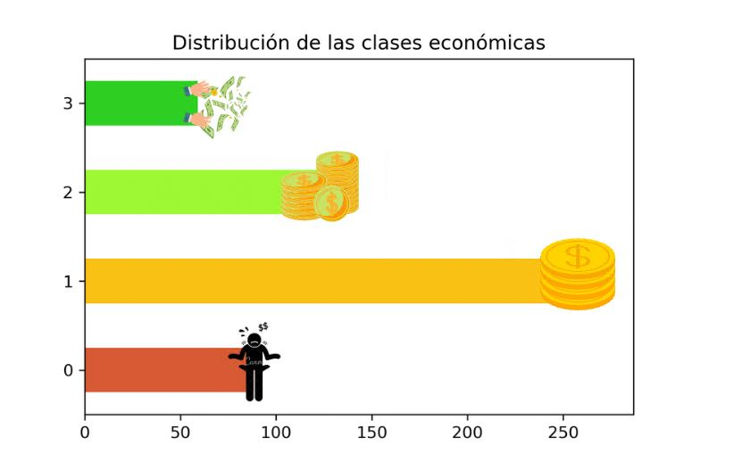

#### Variables

- fb_id: Identificador que se usa para cruzar con la BBDD.
- fb_bio: Biografía del usuario, se usa principalmente para intentar parsear la localización.
- fb_currently_living: Campo que indica el lugar de residencia actual del usuario, se utiliza principalmente para intentar parsear la localización.
- fb_birth_place: Campo que indica el lugar de nacimiento del usuario, se utiliza principalmente para intentar parsear la localización.
- fb_education: Campo que indica el lugar donde realizó sus últimos estudios el usuario, se utiliza principalmente para intentar parsear la localización.
- fb_experience: Campo que indica el último puesto de trabajo del usuario, se utiliza principalmente para intentar parsear la localización.
- fb_friends: Esta variable indica el número de amigos en Facebook del usuario.
- fb_nPublications: Número total de publicaciones realizadas por el usuario.
- fb_nInterests: Número total de páginas o grupos de interés marcados por el usuario.
- fb_Likes_per_pub: Media de likes que recibe el usuario en las publicaciones.
- fb_Shares_per_pub: Número de veces que se comparten, en media, las publicaciones del usuario.
- fb_Comments_per_pub: Número de comentarios que recibe, en media, el usuario en las publicaciones.
- fb_post_frequency: Frecuencia media, en milisegundos, de posteo en el usuario.
- avg_words_publication: Número medio de palabras en los encabezados de las publicaciones realizadas por el usuario.
- persons_per_pic: Media de personas que aparecen en cada foto publicada por el usuario.
- smilespercentage: Porcentaje de fotos en en las que aparece alguna sonrisa posteadas por el usuario.
- indoors_pic_percentage: Porcentaje de fotos en interiores posteadas por el usuario.
- outdoors_pic_percentage: Porcentaje de fotos en exteriores posteadas por el usuario.
- texts_pic_percentage: Porcentaje de fotos en posteadas por el usuario en las que aparece texto (hace referencia por ejemplo a las típicas fotos que se comparten en cadenas).
- nature_pic_percentage: Porcentaje de fotos publicadas por el usuario en las que se detecta naturaleza (campo, montaña…).
- beach_pic_percentage: Porcentaje de fotos en la playa publicadas por el usuario.
- outfit_pic_percentage: Porcentaje de fotos en las que se detecta un elemento destacado de vestimenta (sombrero, gafas de sol, vestido o calzado).
- food_pic_percentage: Porcentaje de fotos en las que se detecta comida de entre las publicadas por el usuario.
- memes_pic_percentage: Porcentaje de fotos identificadas como memes.
- sport_pic_percentage: Porcentaje de fotos en las que aparecen elementos deportivos (bicicleta, pelota, skies…).
- snow_pic_percentage: Porcentaje de fotos en las que se detecta nieve. Por lo general es muy bajo, pero era un elemento diferencial de la clases económicas altas (muchos viajes y actividades recreativas).
- skyscraper_pic_percentage: Porcentaje de fotos en las que se detecta un rascacielos. Igual que la variable anterior suele presentar un porcentaje muy bajo, pero de nuevo es un buen elemento característico de las clases altas.
- Asuntos sociales: Hace referencia a la afinidad a este campo, calculada en función al número de intereses pertenecientes al mismo presentados por el usuario.
- Cultura y educación: Hace referencia a la afinidad a este campo, calculada en función al número de intereses pertenecientes al mismo presentados por el usuario.
- Actualidad:Hace referencia a la afinidad a este campo, calculada en función al número de intereses pertenecientes al mismo presentados por el usuario.
- Empresa, economía, finanzas: Hace referencia a la afinidad a este campo, calculada en función al número de intereses pertenecientes al mismo presentados por el usuario.
- Entretenimiento: Hace referencia a la afinidad a este campo, calculada en función al número de intereses pertenecientes al mismo presentados por el usuario.
- Moda: Hace referencia a la afinidad a este campo, calculada en función al número de intereses pertenecientes al mismo presentados por el usuario.
- Salud y belleza: Hace referencia a la afinidad a este campo, calculada en función al número de intereses pertenecientes al mismo presentados por el usuario.
- Gastronomía: Hace referencia a la afinidad a este campo, calculada en función al número de intereses pertenecientes al mismo presentados por el usuario.
- Espectáculo: Hace referencia a la afinidad a este campo, calculada en función al número de intereses pertenecientes al mismo presentados por el usuario.
- Cine, TV y series: Hace referencia a la afinidad a este campo, calculada en función al número de intereses pertenecientes al mismo presentados por el usuario.
- fb_final_economy: Indicador económico final obtenido gracias al enriquecimiento de los datos.
- Clase económica: Variable target obtenida según el etiquetado basado en el conocimiento de negocio.

#### Correlaciones

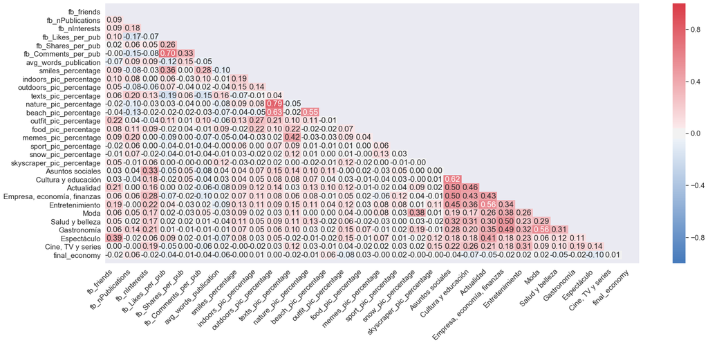

Vemos, en la figura anterior, la matriz de correlaciones entre nuestros predictores. Como se puede observar, por lo general, no tenemos correlaciones excesivamente altas; de hecho no hay ninguna (en valor absoluto) por encima de 0,8. De entre las más altas destacan:

- La correlación más alta (0,79) se presenta entre las variables nature_pic_percentage y outdoors_pic_percentage. Esto tiene mucho sentido, ya que parece evidente que exteriores y naturaleza pueden llegar a ser en muchos casos sinónimos. En este caso, podríamos plantearnos más adelantes eliminar una de estas dos variables.
- Otra de las correlaciones más altas (0,7) se da entre las variables fb_Comments_per_pub y fb_Likes_per_pub. También parece normal que estos predictores vayan de la mano, puesto que ambos son indicadores directamente proporcionales a la popularidad de una publicación.
- Destaca también que la zona inferior derecha de la matriz es donde más valores altos agrupados se detectan. Esta zona mide las correlaciones entre las variables que versan sobre los intereses, por lo tanto hace indicar que, las personas, o no marcan ningún interés, o cuando marcan, marcan bastantes.
- Por último, resulta curioso que, se observan valores muy bajos en las correlaciones negativas (se puede ver que no hay azules oscuros). En particular, la correlación más negativa es la que presentan texts_pic_percentage y fb_Likes_per_pub.

#### Transformaciones

En vista de las distribuciones tan asimétricas que estamos obteniendo, se prueba qué tal resultaría cada una de las variables transformadas primero mediante el logaritmo y después mediante la raíz cuadrada, con el objetivo de normalizarlas.

Observando dichas transformaciones, el logaritmo funciona mejor que la raíz en este caso, pero no mejora todas las variables. Por tanto, se toma la decisión de aplicarlo a las que más mejora, que son las siguientes: fb_nInterests, fb_Likes_per_pub, fb_Comments_per_pub, avg_words_publication, smiles_percentage, indoors_pic_percentage, outdoors_pic_percentage, Asuntos sociales, Cultura y educación, Actualidad, Empresa_economía_finanzas, Entretenimiento, Moda, Salud_y_belleza, Gastronomía, Espectáculo, Cine_TV_series, final_economy. Mostramos a continuación en la figura, a modo de ejemplo, el efecto producido con la transformación en una de estas variables.

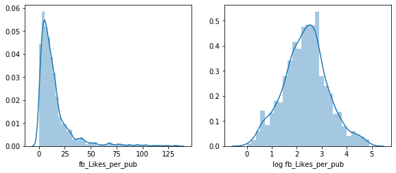

#### Importancia de variables

En nuestro caso tenemos un número considerablemente alto de características para un número bajo de observaciones, por lo tanto podemos estar cayendo en este problema. Para tratar de evitarlo, vamos a quitarnos de nuestro modelo todas aquellas que aporten poco o nada a nuestro modelo. Una manera elegante de hacer esto es mirar aquellas variables con los coeficientes (en valor absoluto) más bajos en una regresión logística pero, como se ha comentado anteriormente, las regresiones logísticas solo funcionan para problemas binarios. Luego, usaremos en su lugar un árbol de decisión simple. La idea subyacente es la misma, las variables más importantes serán aquella en las que el árbol se basa para realizar las primeras separaciones, ya que serán las más discriminatorias. Aplicando está técnica obtenemos el ranking que se muestra a continuación.

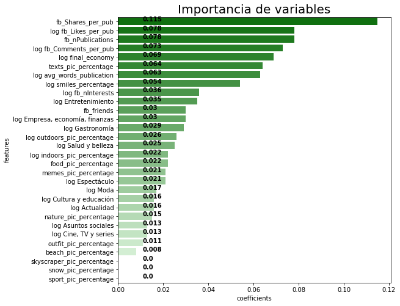

Volver arriba

### Resultados

Se muestran en la continuación dos gráficas, en la primera de ellas podemos ver en concreto el desempeño de cada modelo según los resultados obtenidos al evaluar los resultados contra la métrica QWKS y en la segunda se añaden también los resultados en función del accuracy obtenido.

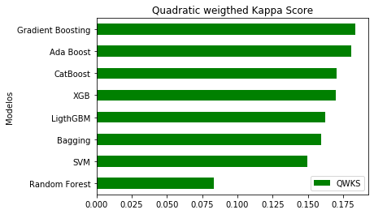

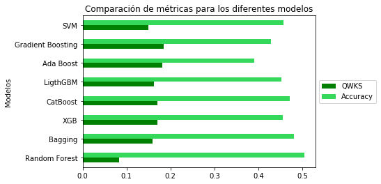

Observamos que Gradient Boosting y Ada Boost son los que mejor QWKS obtienen. En general, vemos que los algoritmos de boosting obtienen son los que mejores resultados obtienen, esto suele ocurrir, pero tienen la pega de que son poco explicativos. Es curioso que el Random Forest aun habiendo optimizado hiperparámetros arroja resultados bastante pobres.

No deja de resultar curioso que los algoritmos que mejores resultados con respecto a accuracy tienen, son los peores en QWKS, lo que es consecuencia de que efectivamente aciertan más, pero los fallos se producen entre clases distanciadas. Esto es que es un claro indicador que una buena elección de la métrica con respecto a la que optimizar es una parte muy importante de la elaboración de modelos de Machine Learning.

A continuación se muestra en el siguiente gráfico una representación a modo de diagrama de cajas que muestra los resultados del modelos en las diferentes estapas del proceso de cross validation, esta vez para la métrica cohen kappa en su vertiente sin pesos.

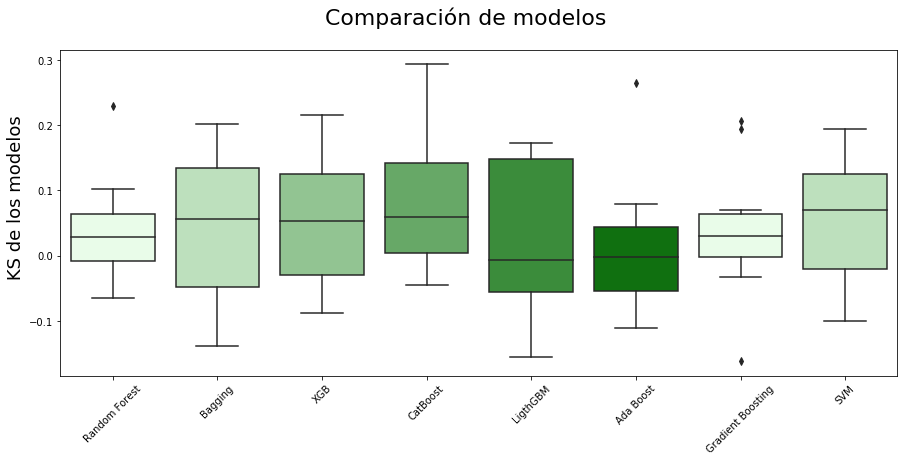

Es interesante comprobar también los rendimientos en esta versión de la métrica, pues la alternativa cuadrática cae mucho más rápido cuando el desacuerdo es entre categorías lejanas. Y en ciertos casos, fallar entre un 0 y un 3 podría llegar a ser lo mismo que fallar entre un 3 y un 1, por tanto no está de más tener también la visión de esta vertiente. Además, viendo los resultados arrojados, resulta curioso que modelos que antes no destacaban como Support Vector Machines o CatBoost se encuentren ahora entre los mejores, mientras que Ada Boost y Gradient Boosting ahora no destacan, de hecho se encuentran entre los peores.

Volver arriba

## LinkedIn

El gran problema de esta red social en nuestro problema es que nuestro target son alumnos pre universitarios o post universitarios recién titulados que puedan estar en disposición de cursar un máster o hacer un doctorado. Es por eso que muchos de ellos tendrán poca o nula experiencia laboral, lo que genera pocas posibilidades de que tengan un perfil en esta red.

### Enriquecimiento

El enriquecimiento se nutre, básicamente, de la misma información que el modelo de Facebook.Con la diferencia de que los campos en los que tratar de parsear una localización son diferentes en este caso. En LinkedIn damos más importancia a aquellas localizaciones detectadas en el último puesto de trabajo o últimos estudios, mientras que Facebook lo que más premiaba era la biografía.

### Análisis exploratorio

#### Distribución de las clases

En este caso, la distribución de las clases en los 100 usuarios para los que disponemos de información es la siguiente:

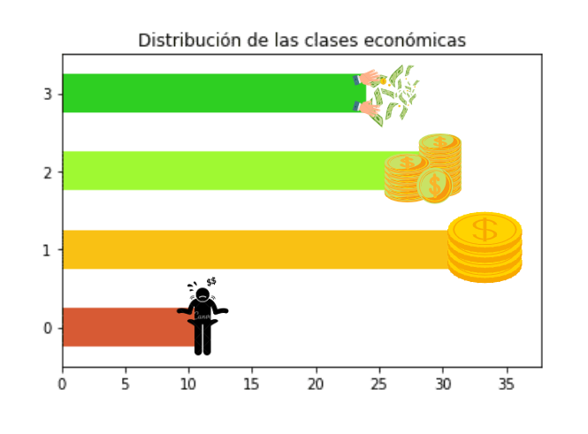

Podemos ver en la figura que en este caso que las clases son más parejas que en Facebook, salvando la 0. Esto era de esperar en primer lugar porque tenemos bastantes menos datos. En segundo lugar porque es más fácil detectar gente de las clases más altas por el tipo de cargo que ocupan. Eso sí, es complicado encontrar perfiles de clase 0, pues este tipo de perfiles suele ostentar trabajos que no tienen mucha presencia en LinkedIn.

#### Variables

- Lkd_id_: Identificador que se usa para cruzar con la BBDD.
- Lkd_bio: Extracto que el usuario publica sobre sí mismo, normalmente se encuentran profesiones, especialidades e intereses.
- Lkd_nSkills: Número de habilidades o aptitudes que el usuario ha declarado, en LinkedIn, poseer.
- Lkd_nExperiences: Número de puestos de trabajo que ha ocupado.
- Lkd_nEducations: Número de ítems en el campo educación (por ejemplo, si se encuentra una grado, un máster y un doctorado, este número sería 3).
- Lkd_nInterests: Número total de intereses marcados por el usuario.
- Lkd_nAwards: Número total de ítems en el campo ``logros’’.
- Lkd_nLicences: Número total de ítems en el campo ``licencias y certificaciones’’.
- Lkd_nRecommendationsBy: Número total de recomendaciones que ha recibido el usuario.
- Lkd_nRecommendationsTo: Número total de recomendaciones que ha realizado el usuario.
- Lkd_Posgraduated: Variable binaria que indica si el usuario ha cursado, o no, estudios post universitarios. Se ha conseguido buscando coincidencias con un diccionario de palabras como “máster”, “maestría”, “phD”, “doctorado”…
- Lkd_ImportantPosition: Variable binaria que indica si el usuario ha ostentado, o no, altos puestos. Se ha conseguido buscando coincidencias con un diccionario de palabras como “CEO”, “partner”, “mánager”, “jefe”…
- Lkd_PrivateUniversity: Variable binaria que indica si el usuario ha cursado estudios en una universidad privada o no. Esta variable se ha conseguido cruzando los datos con una lista de todas las universidades privadas tanto latinoamericanas como españolas.
- final_economy: Indicador económico obtenido según los datos de enriquecimiento.

### Resultados

Podemos observar en el primer y tercer gráfico de la figura que en este caso el algoritmo que mejor ha funcionado se trata del XGBoost. También se observa que en general los resultados obtenidos para esta red social, en términos de la QWKS son considerablemente mejores que los obtenidos para Facebook. Esto posiblemente venga debido en primer lugar a que aquí tenemos muy pocos datos por lo que las predicciones serán menos fiables, y por otro lado porque, tal y como hemos comentado anteriormente, es una red social enfocada a un tipo de trabajo que suele asociarse más a clases media o alta.

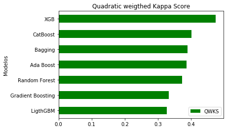

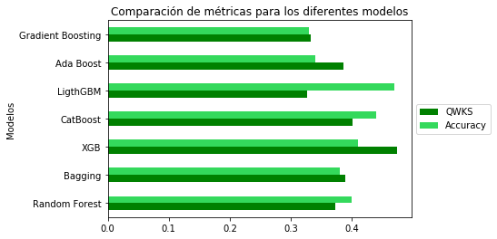

Por último, también resulta curioso que, como se puede ver en el segundo de los histogramas, tenemos ahora casos en los que los resultados de QWKS son más alto que los de Accuracy, cosa que no habíamos ambas métricas.

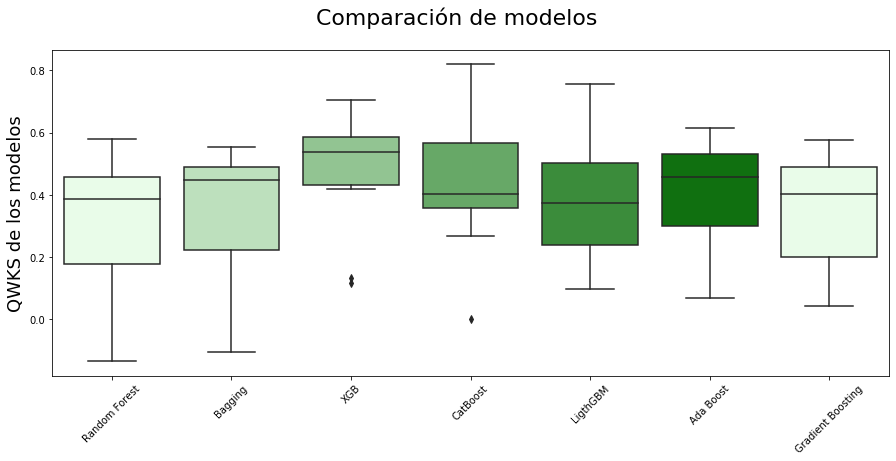

Volver arriba

## Twitter

Se trata de la red social menos independiente, es decir, la que menos aporta por sí misma como para realizar una predicción económica. No obstante, es un complemento ideal para las otras dos. Por tanto, se mostrarán en esta sección aquellas variables e información que hemos obtenido de esta red social, de cara a un futuro algoritmo conjunto, pero no se elaborarán modelos, ya que la idea de Twitter es complementar la información y servir de apoyo a Facebook y LinkedIn.

### Distribución de las clases

Como se ha comentado anteriormente, Twitter se trata de la red sociales que más dificultades presenta para el etiquetado, por ello no lleva asociado un modelo. Aun así, las clases se distribuyen como se muestra en la imagen:

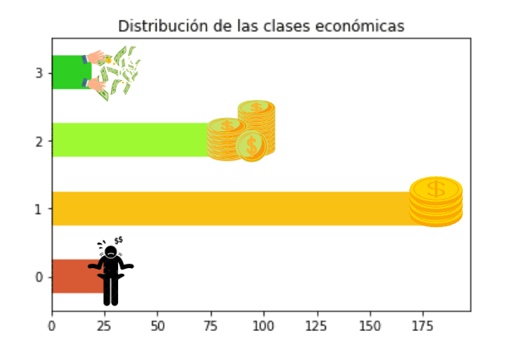

### Variables

Puesto que Twitter es una red social que se basa en publicar mensajes de no más de 250 caracteres, nos enfocaremos sobre todo en variables que puedan servir para medir el nivel ortográfico, son las siguientes:

- tw_id_: Identificador que se usa para cruzar con la BBDD.
- tw_nickName: Nickname usado por el usuario.
- tw_bio: Biografía del usuario.
- tw_public: Variable binaria que indica si el perfil es, o no, público.
- tw_nlikes: Número total de likes que ha dado el usuario.
- tw_nShares: Número total de Retweets que ha dado el usuario.
- tw_nFollowers: Número de cuentas que siguen el perfil del usuario.
- tw_nFollowing: Número de cuentas a las que el usuario sigue.
- tw_nPubliclations: Número total de publicaciones realizadas por el usuario.
- avg_likes_per_pub: Número medio de likes que recibe el usuario en sus publicaciones.
- avg_shares_per_pub: Número medio de retweets que recibe el usuario en sus publicaciones.
- avg_replies_per_pub: Número medio de respuestas que recibe el usuario en sus publicaciones.
- avg_characters_per_pub: Número medio caracteres que el usuario escribe en sus publicaciones.
- avg_words_per_pub: Número medio de palabras que el usuario escribe en sus publicaciones.
- avg_longwords_per_pub: Número medio de palabras largas (más de 6 letras) que el usuario escribe en sus publicaciones.
- avg_punctuations_per_pub: Número medio de signos de puntuación que el usuario escribe en sus publicaciones.
- avg_hastags_per_pub: Número medio de hastagas que el usuario escribe en sus publicaciones.
- avg_mentions_per_pub: Número medio de usuarios mencionados en las publicaciones del usuario.
- avg_emojis_per_pub: Número medio de emoticonos usados por el usuario en sus tweets.
- tw_oldness: Antiguedad de la cuenta, esta variable se crea a partir de la fecha de creación de la cuenta.